# HaVu_exam2

Vu Thi-Hong-Ha

April 20, 2020

First, I extracted all website links to scrape data:

```r
web <- "https://countryeconomy.com/countries"
html <- read_html(web)

subweb <- html %>% html_nodes("h4 a") %>% html_attr("href")

for (i in 1:length(subweb)) {
  subweb[i] <- paste("https://countryeconomy.com", subweb[i], sep = "")
}
```

Then I choose to look at 19 Asian countries: China, Indonesia, Malaysia, Myanmar, Philippines, South Korea“, Singapore, Thailand, Vietnam, Bangladesh, Pakistan, Sri Lanka, Israel, Jordan, Qatar, Saudi Arabia, Syria, Turkey, and Yemen. The variables (12 variables in total) I choose to look at are: GDP Growth (%), Education Expenditure (%Bud.), Gov. Health Exp. (%Bud.), Defence Expenditure (%Bud.), Unemployment rate (LFS), Top tax rate + SSC, Exports % GDP, Imports % GDP, Birth Rate, Fertility Rate, Population, and CO2 Tons per capita.

```r
countries <- c("china", "indonesia", "malaysia", "burma", "philippines", "south-korea", "singapore", "thailand", "vietnam",
               "bangladesh", "pakistan", "sri-lanka",
               "israel", "jordan", "qatar", "saudi-arabia", "syria", "turkey", "yemen")
countries <- sort(countries)
country_urls <- vector()
for (i in 1:length(subweb)) {
  if ("TRUE" %in% str_contains(subweb[i], countries)) {
    temp <- subweb[i]
    country_urls <- c(country_urls, temp)
  }
}

#annual gdp ====
gdp <- tibble()

for (i in 1:length(country_urls)) {
  web1 <- read_html(country_urls[i]) %>% html_nodes("a") %>% html_attr("href") %>% grep("gdp", ., value = T) %>%
    unique() %>% grep(countries[i], ., value = T) %>% paste("https://countryeconomy.com", ., sep = "")
  tables <- read_html(web1) %>% html_table(fill=TRUE)
  for (j in 1:length(tables)) {
    if ("GDP Growth (%)" %in% colnames(tables[[j]])) {
      temp <- tables[[j]]
    }
  }
  temp$Country <- rep(countries[i], nrow(temp))
  temp <- temp[, c("Date", "Country", "GDP Growth (%)")]
  gdp <- rbind(gdp, temp)
}

gdp$`GDP Growth (%)` <- as.numeric(gsub('[\\%,]', '', gdp$`GDP Growth (%)`))
gdp <- gdp[complete.cases(gdp) ,]
meanGDP <- gdp[, -1] %>% group_by(Country) %>% summarise_all(mean)
#====

#expenditure ====
expenditure <- tibble()

for (i in 1:length(country_urls)) {
  web1 <- read_html(country_urls[i]) %>% html_nodes("a") %>% html_attr("href") %>% grep("expenditure", ., value = T) %>%
    unique() %>% grep(countries[i], ., value = T) %>% paste("https://countryeconomy.com", ., sep = "")
  tables <- read_html(web1[1]) %>% html_table(fill=TRUE)
  tables[[1]]$Country <- rep(countries[i], nrow(tables[[1]]))
  tables[[1]] <- tables[[1]][, c("Date", "Country", "Education Expenditure (%Bud.)", "Gov. Health Exp. (%Bud.)",
                                 "Defence Expenditure (%Bud.)")]
  expenditure <- rbind(expenditure, tables[[1]])
}

expenditure$`Education Expenditure (%Bud.)` <- as.numeric(gsub('[\\%,]', '', expenditure$`Education Expenditure (%Bud.)`))
expenditure$`Gov. Health Exp. (%Bud.)` <- as.numeric(gsub('[\\%,]', '', expenditure$`Gov. Health Exp. (%Bud.)`))
expenditure$`Defence Expenditure (%Bud.)` <- as.numeric(gsub('[\\%,]', '', expenditure$`Defence Expenditure (%Bud.)`))
expenditure <- expenditure[complete.cases(expenditure) ,]
meanExpenditure <- expenditure[, -1] %>% group_by(Country) %>% summarise_all(mean)
#====

#unemployment rate ====
rate <- vector()

for (i in 1:length(country_urls)) {
  web1 <- read_html(country_urls[i]) %>% html_nodes("a") %>% html_attr("href") %>% grep("labour-force-survey", ., value = T) %>%
    unique() %>% grep(countries[i], ., value = T) %>% paste("https://countryeconomy.com", ., sep = "")
  tables <- read_html(web1[1]) %>% html_table(fill=TRUE)
  rate <- c(rate, tables[[1]][1, 2])
}

unemployment <- tibble(.rows = length(rate))
unemployment$Country <- countries
unemployment$`Unemployment rate (LFS)` <- as.numeric(gsub('[\\%,]', '', rate))

#====

#personal income tax====
tax <- tibble()

for (i in 1:length(country_urls)) {
  web1 <- read_html(country_urls[i]) %>% html_nodes("a") %>% html_attr("href") %>% grep("taxes/personal-income-tax", ., value = T) %>%
    unique() %>% grep(countries[i], ., value = T) %>% paste("https://countryeconomy.com", ., sep = "")
  tables <- read_html(web1[1]) %>% html_table(fill=TRUE)
  temp <- tables[[1]]
  temp$Country <- rep(countries[i], nrow(temp))
  temp <- temp[, c("Date", "Country", "Top tax rate + SSC")]
  tax <- rbind(tax, temp)
}
tax$`Top tax rate + SSC` <- as.numeric(gsub('[\\%,]', '', tax$`Top tax rate + SSC`))
meanTax <- tax[, -1] %>% group_by(Country) %>% summarise_all(mean)

#====

#exports ====
exports <- tibble()

for (i in 1:length(country_urls)) {
  web1 <- read_html(country_urls[i]) %>% html_nodes("a") %>% html_attr("href") %>% grep("trade/exports", ., value = T) %>%
    unique() %>% grep(countries[i], ., value = T) %>% paste("https://countryeconomy.com", ., sep = "")
  tables <- read_html(web1[1]) %>% html_table(fill=TRUE)
  temp <- tables[[1]]
  temp$Country <- rep(countries[i], nrow(temp))
  temp <- temp[, c("Date", "Country", "Exports % GDP")]
  exports <- rbind(exports, temp)
}
exports$`Exports % GDP` <- as.numeric(gsub('[\\%,]', '', exports$`Exports % GDP`))
exports <- exports[complete.cases(exports) ,]
meanExports <- exports[, -1] %>% group_by(Country) %>% summarise_all(mean)
#====

#imports ====
imports <- tibble()

for (i in 1:length(country_urls)) {
  web1 <- read_html(country_urls[i]) %>% html_nodes("a") %>% html_attr("href") %>% grep("trade/imports", ., value = T) %>%
    unique() %>% grep(countries[i], ., value = T) %>% paste("https://countryeconomy.com", ., sep = "")
  tables <- read_html(web1[1]) %>% html_table(fill=TRUE)
  temp <- tables[[1]]
  temp$Country <- rep(countries[i], nrow(temp))
  temp <- temp[, c("Date", "Country", "Imports % GDP")]
  imports <- rbind(imports, temp)
}
imports$`Imports % GDP` <- as.numeric(gsub('[\\%,]', '', imports$`Imports % GDP`))
imports <- imports[complete.cases(imports) ,]
meanImports <- imports[,-1] %>% group_by(Country) %>% summarise_all(mean)

#====

#fertility ====
#note: fertility rate and birth rate is in ‰
fertility <- tibble()

for (i in 1:length(country_urls)) {
  web1 <- read_html(country_urls[i]) %>% html_nodes("a") %>% html_attr("href") %>% grep("/demography/fertility", ., value = T) %>%
    unique() %>% grep(countries[i], ., value = T) %>% paste("https://countryeconomy.com", ., sep = "")
  tables <- read_html(web1[1]) %>% html_table(fill=TRUE)
  temp <- tables[[1]]
  temp$Country <- rep(countries[i], nrow(temp))
  temp <- temp[, c("Date", "Country", "Birth Rate", "Fertility Rate")]
  fertility <- rbind(fertility, temp)
}
fertility$`Birth Rate` <- as.numeric(gsub('[\\‰,]', '', fertility$`Birth Rate`))
fertility$`Fertility Rate` <- as.numeric(fertility$`Fertility Rate`)
fertility <- fertility[complete.cases(fertility) ,]
meanFertility <- fertility[, -1] %>% group_by(Country) %>% summarise_all(mean)
#====

#population ====
population <- tibble()

for (i in 1:length(country_urls)) {
  web1 <- read_html(country_urls[i]) %>% html_nodes("a") %>% html_attr("href") %>% grep("/demography/population", ., value = T) %>%
    unique() %>% grep(countries[i], ., value = T) %>% paste("https://countryeconomy.com", ., sep = "")
  tables <- read_html(web1[1]) %>% html_table(fill=TRUE)
  temp <- tables[[1]]
  temp$Country <- rep(countries[i], nrow(temp))
  temp <- temp[, c("Date", "Country", "Population")]
  population <- rbind(population, temp)
}
population$Population <- as.numeric(gsub(",", '', population$Population))
population$Population <- population$Population / 10**6 #unit = million
meanPop <- population[, -1] %>% group_by(Country) %>% summarise_all(mean)
#====

#co2 ====
co2 <- tibble()

for (i in 1:length(country_urls)) {
  web1 <- read_html(country_urls[i]) %>% html_nodes("a") %>% html_attr("href") %>% grep("/energy-and-environment/co2-emissions", ., value = T) %>%
    unique() %>% grep(countries[i], ., value = T) %>% paste("https://countryeconomy.com", ., sep = "")
  tables <- read_html(web1[1]) %>% html_table(fill=TRUE)
  temp <- tables[[1]]
  temp$Country <- rep(countries[i], nrow(temp))
  temp <- temp[, c("Date", "Country", "CO2 Tons per capita")]
  co2 <- rbind(co2, temp)
}
meanCO2 <- co2[, -1] %>% group_by(Country) %>% summarise_all(mean)
#====
```

Because data in each category of each country is recorded differently, some countries has data across a long period of time, some do not, so for now, I analyze the mean value of each category of every country. This resulted in a data set as below:

```r
data <- join_all(list(meanGDP, meanExpenditure, unemployment,
                      meanTax, meanExports, meanImports,
                      meanFertility, meanPop, meanCO2), by = "Country", type = "left")
data$Region <- c("south", "east", "east", "east", "western", "western",
                 "east", "south", "east", "western", "western", "east",
                 "east", "south", "western", "east", "western", "east", "western")
head(data)
```

```
##      Country GDP Growth (%) Education Expenditure (%Bud.)
## 1 bangladesh       4.454167                      16.37867
## 2      burma       5.945833                       3.15250
## 3      china       8.870833                      16.35250
## 4  indonesia       5.900000                      14.66824
## 5     israel       4.393750                      13.46063
## 6     jordan       4.566667                      16.92500
##   Gov. Health Exp. (%Bud.) Defence Expenditure (%Bud.) Unemployment rate (LFS)
## 1                 4.865333                   10.520667                     4.4
## 2                 1.255000                   10.542500                     1.0
## 3                14.580000                   14.245000                     4.1
## 4                 4.790000                    4.766471                     4.4
## 5                10.008125                   16.073125                     4.2
## 6                14.075000                   17.075000                    15.8
##   Top tax rate + SSC Exports % GDP Imports % GDP Birth Rate Fertility Rate
## 1           26.56250      8.856809      15.00936   35.37155       4.747069
## 2           22.50000     13.450408      14.22857   30.21397       4.039655
## 3           45.00000     13.981525      12.64458   20.57638       3.036724
## 4           31.87500     21.128868      16.20811   29.40086       3.741897
## 5           56.88421     19.749831      30.34492   23.33103       3.223276
## 6           20.25000     19.109444      53.71593   38.27293       5.771207
##    Population CO2 Tons per capita  Region
## 1  104.939666           0.2067347   south
## 2   38.973216           0.2079592    east
## 3 1012.566929           3.4361224    east
## 4  174.360903           1.1228571    east
## 5    5.055780           7.7804082 western
## 6    4.081854           2.5906122 western
```

Define some important functions:

```r
#functions
QQplot.normal <- function(x) {
  # x is an observed vector of a variable
  x.sort <- sort(x)
  n <- length(x)
  p <- ( c(1 : n) - 0.5 ) / n
  q <- qnorm(p)
  res <- data.frame(cbind(x.sort, q))
  names(res) <- c("sample.quantile", "normal.quantile")
  return(res)
}

testnormality <- function(X, numproj = 100000) {
  # note that the value returned is the q-value of the test
  p = ncol(X)
  n = nrow(X)
  x <- matrix(rnorm(numproj * p), nrow = p)
  y <- matrix(sqrt(apply(x^2, 2, sum)), nrow = p, ncol = numproj, by = T)
  z <- x / y
  tempdat <- as.matrix(X) %*% z
  pvals <- apply(tempdat, 2, function(x) shapiro.test(x)$p.value)
  return(min(sort(pvals) * numproj / (1:numproj)))
}
```

First, let’s take a look at the data to see if there is any potential outliers. Here, I plot Q-Q plots of the variables, but plot `Population` separately because its scale is too large:

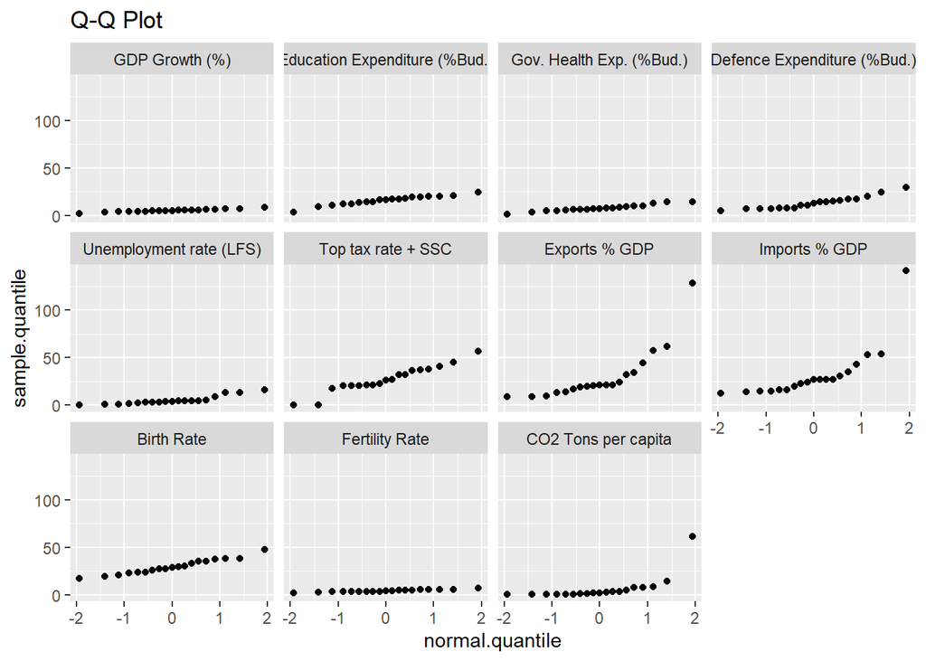

```r
#make Q-Q plots
#plot population separately because its scale is too large
data[, which(!(colnames(data) %in% c("Country", "Population", "Region")))] %>% reshape2::melt() %>% group_by(variable) %>%  dplyr::summarise(x = list(QQplot.normal(value))) %>% unnest(cols = c(x)) %>%
  qplot(x = normal.quantile, y = sample.quantile, data = ., facets = ~ variable, main = "Q-Q Plot")
```

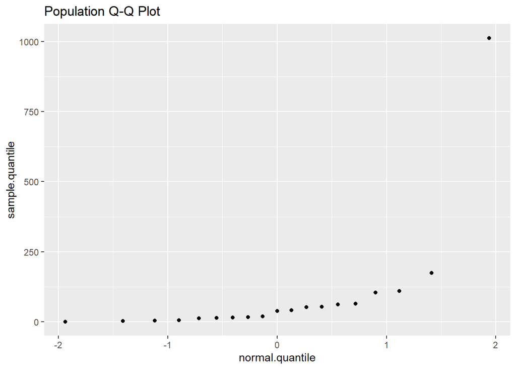

```r
#plot population Q-Q plot
ggplot(data = QQplot.normal(data[, which(colnames(data) %in% c("Population"))]), aes(x = normal.quantile, y = sample.quantile)) + geom_point() +  ggtitle("Population Q-Q Plot")
```

Looking at these plots, we can see that some observations may have very extreme values in `Population`, `Export`, `Import` and `CO2`. I plot those varibles specifically to see which observations stand out:

[figure not shown]

We can see that `China`, `Singapore` and `Qatar` are outliers with very extreme values. Therefore, I excluded these countries from downstream analyses. This results in me having 16 observations.

Next, **test for normality** of the data. Null hypothesis is the data is multivariate normal:

```r
energy::mvnorm.test(data[which(!(data$Country %in% c("china", "qatar", "singapore"))), which(!(colnames(data) %in% c("Country", "Region")))], R = 1e4)
```

```
##
##  Energy test of multivariate normality: estimated parameters
##
## data:  x, sample size 16, dimension 12, replicates 10000
## E-statistic = 1.7531, p-value = 0.1212
```

```r
print("Shapiro Wilk's test:")
```

```
## [1] "Shapiro Wilk's test:"
```

```r
testnormality(data[which(!(data$Country %in% c("china", "qatar", "singapore"))), which(!(colnames(data) %in% c("Country", "Region")))])
```

```
## [1] 0.3419833
```

We fail to reject the null that the data is multivariate normal at the 5% significance level.

Next, I divide the countries of interest into two geographic regions: East Asia and South - Western Asian. I hypothesize that the mean economic metrics of the two regions are equal. We can test this **inference of means** by using Hotelling’s T2 test. But first, we need to see if the two regions have similar covariance matrices.

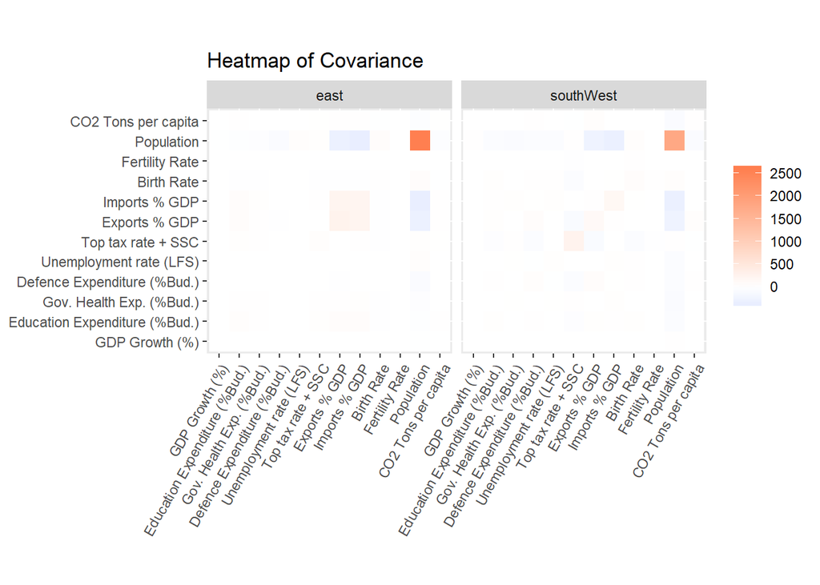

```r
east <- subset(data, data$Region == "east")
east <- east[which(!(east$Country %in% c("china", "singapore"))) ,]

southWest <-  subset(data, data$Region != "east")
southWest <- southWest[which(!(southWest$Country %in% c("qatar"))) ,]

eastCov <- cov(east[, -c(1, 14)])
southWestCov <- cov(southWest[, -c(1, 14)])

data1 <- rbind(east, southWest)
data1$Region <- gsub("south", "southWest", data1$Region)
data1$Region <- gsub("western", "southWest", data1$Region)

data1[, -1] %>% nest(data = -Region) %>%
  dplyr::mutate(cov = map(data, ~ reshape2::melt(var(.)))) %>%
  dplyr::select(-data) %>% unnest(cols = c(cov)) %>%
  qplot(Var1, Var2, fill = value, data = ., facets = ~ Region, geom = "tile") +
  labs(title = "Heatmap of Covariance", x = NULL, y = NULL, fill = NULL) +
  scale_fill_gradient2(low = "dodgerblue", mid = "white", high = "coral", midpoint = 0) +
  coord_fixed() + theme(axis.text.x = element_text(angle = 60, hjust = 1))
```

We can see that the covariance matrices have similar patterns, so we can carry out Hotelling’s T2 test to test for equality of means:

```r
ICSNP::HotellingsT2(east[, -c(1, 14)], southWest[, -c(1, 14)])
```

```
##
##  Hotelling's two sample T2-test
##
## data:  east[, -c(1, 14)] and southWest[, -c(1, 14)]
## T.2 = 3.2506, df1 = 12, df2 = 3, p-value = 0.1805
## alternative hypothesis: true location difference is not equal to c(0,0,0,0,0,0,0,0,0,0,0,0)
```

We fail to reject the null that the mean of economic metrics of two regions are equal, at the 5% significance level. If using additional information from UN, we can see that all of the interested countries are developing countries, and most of them have middle income per capita in 2012.

Another way of **inferring for means** is to use one way **MANOVA**:

```r
fit.lm <- lm(as.matrix(data1[, -c(1, 14)]) ~ Region, data = data1)
summary(car::Manova(fit.lm)) %>% print(SSP = F)
```

```
##
## Type II MANOVA Tests:
##
## ------------------------------------------
##
## Term: Region
##
## Multivariate Tests: Region
##                  Df test stat approx F num Df den Df  Pr(>F)
## Pillai            1  0.928583 3.250566     12      3 0.18054
## Wilks             1  0.071417 3.250566     12      3 0.18054
## Hotelling-Lawley  1 13.002263 3.250566     12      3 0.18054
## Roy               1 13.002263 3.250566     12      3 0.18054
```

Next, I would like to introduce time series as a factor to study the economic metrics of the countries. Because `Unemployment Rate` does not have enough time series data, I drop that variable for the next analyses. I also drop the countries that have data for all variables in only one year. Hence, for the next steps, I check for 13 countries and 11 variables.

```r
data2 <- join_all(list(gdp, expenditure, tax, exports, imports,
                      fertility, population, co2), by = c("Date", "Country"), type = "left")
data2 <- data2[complete.cases(data2) ,]
data2 <- subset(data2, !(data2$Country %in% c("china", "qatar", "singapore", "jordan", "yemen")))

for (i in 1:nrow(data2)) {
  if (data2$Country[i] %in% c("bangladesh", "pakistan", "sri-lanka")) {
    data2$Region[i] <- "south"
  }
  else if (data2$Country[i] %in% c("israel", "saudi-arabia", "syria", "turkey")) {
    data2$Region[i] <- "western"
  }
  else {
    data2$Region[i] <- "east"
  }
}
```

I would like to fit a **multivariate regression** model in which 11 variables are responses, and `Region` and `Date` are covariates.

```r
data2$Region <- as.factor(data2$Region)
fit_lm <- lm(as.matrix(data2[, -c(1, 2, 14)]) ~ Region + Date, data = data2)
car::Manova(fit_lm)
```

```
##
## Type II MANOVA Tests: Pillai test statistic
##        Df test stat approx F num Df den Df    Pr(>F)
## Region  2    1.5868   38.053     22    218 < 2.2e-16 ***
## Date    1    0.3176    4.570     11    108 1.122e-05 ***
## ---
## Signif. codes:  0 '***' 0.001 '**' 0.01 '*' 0.05 '.' 0.1 ' ' 1
```

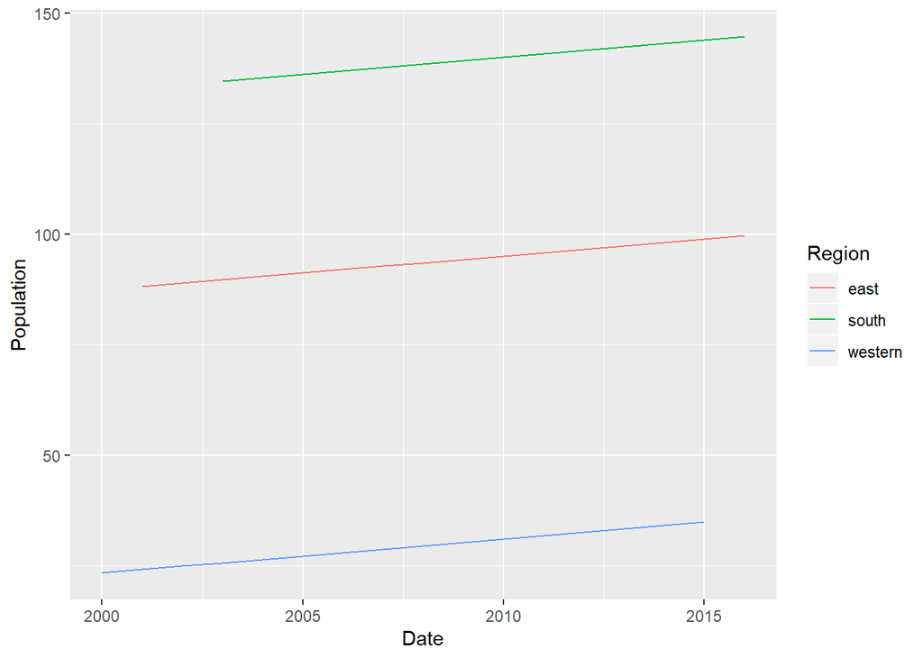

```r
regressLines <- data.frame(data2$Region, data2$Date, fit_lm$fitted.values)
cname <- colnames(data2)
colnames(regressLines) <- c("Region", "Date", cname[-c(1, 5, 14)])
regressLines %>% group_by(Region) %>% ggplot(aes(y = Population, x = Date, colour = Region)) + geom_line()
```

We can see that countries in the Southern Asian tend to have larger population than the other regions. Moreover, the populations of all countries increase over time.

Next, I’m interested in seeing how the countries are separate from each other using PCA.

```r
data2_centered <- data2 %>% select(-Date, -Country) %>% group_by(Region) %>%
  mutate_at(vars(-group_cols()), ~ . - mean(.)) %>% ungroup() %>% select(-Region)
data2_pca <- prcomp(data2_centered)
data2_pca$rotation[, 1:3]
```

```
##                                        PC1         PC2         PC3
## GDP Growth (%)                -0.003928835  0.03425823  0.02362944
## Education Expenditure (%Bud.)  0.014941149  0.04090916  0.11483799
## Gov. Health Exp. (%Bud.)       0.021475441 -0.03904152 -0.04046876
## Defence Expenditure (%Bud.)    0.021040858  0.01319008  0.16346872
## Top tax rate + SSC             0.010452710 -0.40784306 -0.81174333
## Exports % GDP                  0.173674802  0.72513978 -0.08658215
## Imports % GDP                  0.150886922  0.50350257 -0.52025130
## Birth Rate                    -0.029951068  0.09583076  0.06606235
## Fertility Rate                -0.003039314  0.01124890  0.01020896
## Population                    -0.971709016  0.19966150 -0.10060676
## CO2 Tons per capita            0.026337026 -0.02452148  0.07885970
```

```r
source("D:/Coursework/Stat 501 Spring 2020/PCs.proportion.variation.enuff.R")
options(digits = 3)

pvals <- sapply(1:ncol(data2_centered), function(i)
PCs.proportion.variation.enuff(data2_pca$sdev ^ 2, i, .96, nrow(data2_centered)))
rbind(summary(data2_pca)$importance, "P-value" = pvals)[, 1:3]
```

```
##                             PC1     PC2     PC3
## Standard deviation     6.12e+01 16.9478 11.9818
## Proportion of Variance 8.79e-01  0.0675  0.0337
## Cumulative Proportion  8.79e-01  0.9466  0.9803
## P-value                2.43e-07  0.0346  1.0000
```

If we plot the first two PCs, we can see that the countries are well separate; however, they do not separate according to regions. One interesting thing is Pakistan and Bangladesh cluster together, while Sri Landka does not, although all three of them are South Asian. There may be many reasons to explain for this, such as Pakistan and Bangladesh (and India) share a long history (they originally were ruled by the British as Indian subcontient), so the countries may have similar patterns in the society.

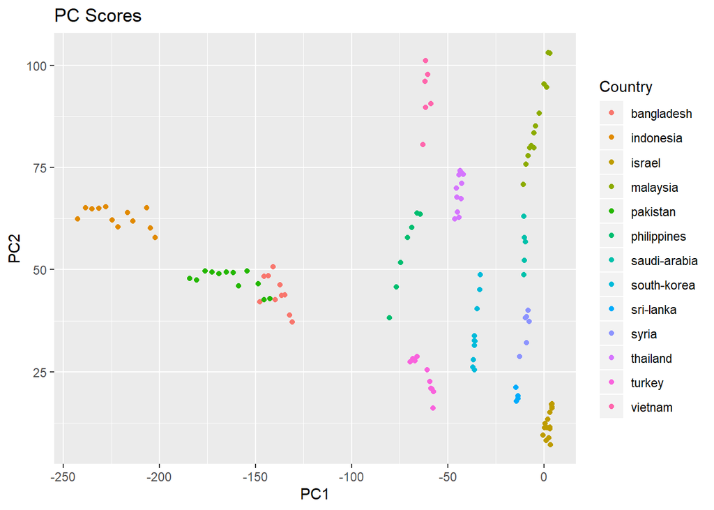

```r
data2_score <- as.matrix(data2[, -c(1, 2, 14)]) %*% data2_pca$rotation
data.frame(data2_score[, 1:2], Country = data2$Country) %>%
  qplot(x = PC1, y = PC2, color = Country, data = ., main = "PC Scores")
```

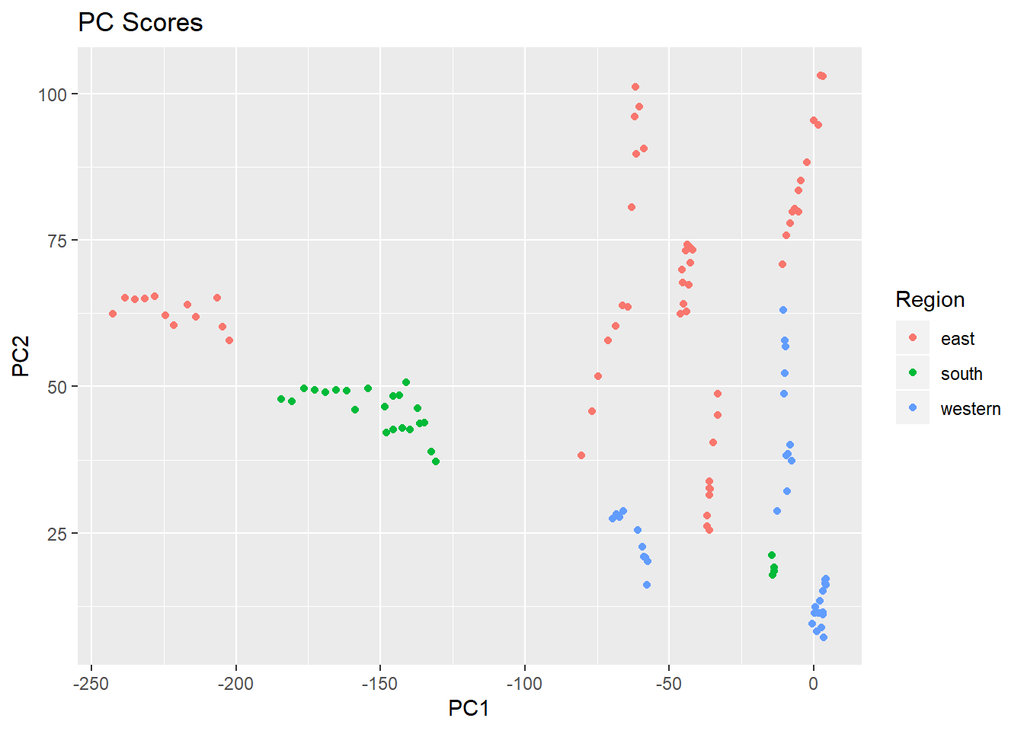

```r
data.frame(data2_score[, 1:2], Region = data2$Region) %>%
  qplot(x = PC1, y = PC2, color = Region, data = ., main = "PC Scores")
```

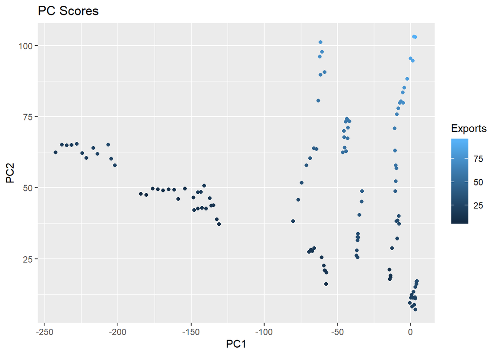

```r
data.frame(data2_score[, 1:2], Exports = data2$`Exports % GDP`) %>%
  qplot(x = PC1, y = PC2, color = Exports, data = ., main = "PC Scores")
```

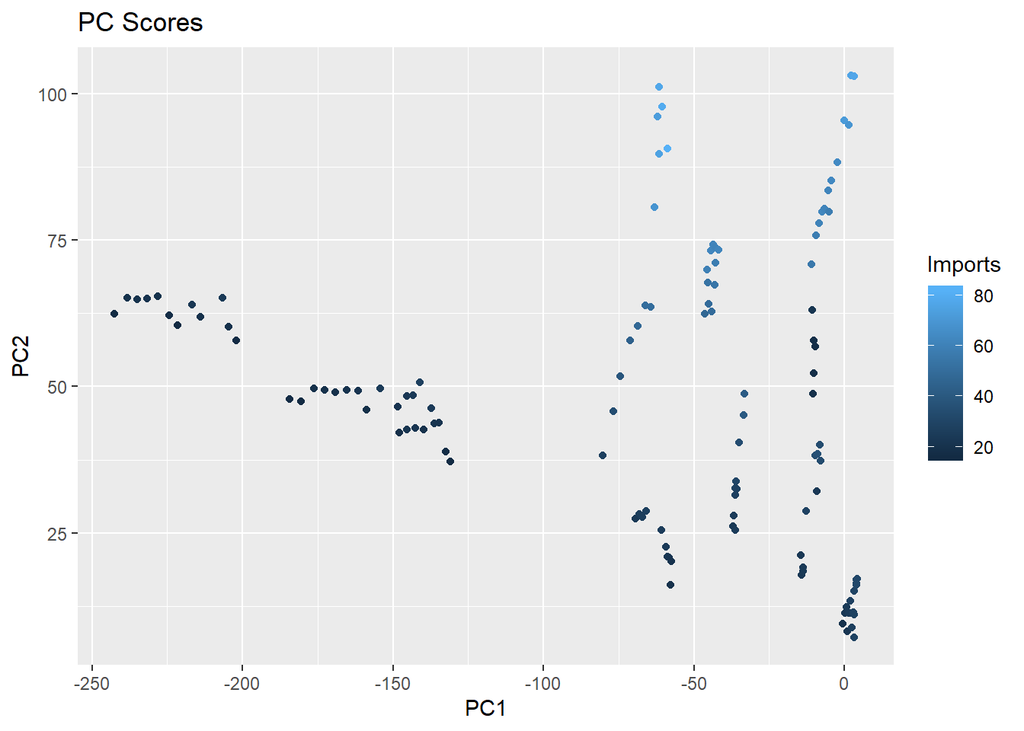

```r
data.frame(data2_score[, 1:2], Imports = data2$`Imports % GDP`) %>%
  qplot(x = PC1, y = PC2, color = Imports, data = ., main = "PC Scores")
```